# FRA Project(Milestone-1)

## FRA Project(Milestone-1)

### Problem Statement

Businesses or companies can fall prey to default if they are not able to keep up their debt obligations. Defaults will lead to a lower credit rating for the company which in turn reduces its chances of getting credit in the future and may have to pay higher interests on existing debts as well as any new obligations. From an investor's point of view, he would want to invest in a company if it is capable of handling its financial obligations, can grow quickly, and is able to manage the growth scale.

A balance sheet is a financial statement of a company that provides a snapshot of what a company owns, owes, and the amount invested by the shareholders. Thus, it is an important tool that helps evaluate the performance of a business.

Data that is available includes information from the financial statement of the companies for the previous year (2015). Also, information about the Networth of the company in the following year (2016) is provided which can be used to drive the labeled field.

### Questions:

1.1 Outlier Treatment

1.2 Missing Value Treatment

1.3 Transform Target variable into 0 and 1

1.4 Univariate & Bivariate analysis with proper interpretation. (You may choose to include only those variables which were significant in the model building)

1.5 Train Test Split

1.6 Build Logistic Regression Model (using statsmodel library) on most important variables on Train Dataset and choose the optimum cutoff. Also showcase your model building approach

1.7 Validate the Model on Test Dataset and state the performance matrices. Also state interpretation from the model

Quality of Business report.(Please refer to the Evaluation Guidelines for Business report checklist. Marks in this criteria are at the moderator's discretion).

```python
#Importing libraries

import numpy as np, pandas as pd
import matplotlib.pyplot as plt
%matplotlib inline
import seaborn as sns
import sklearn.metrics as metrics
color = sns.color_palette()
import warnings
warnings.filterwarnings('ignore')
```

```python
#Loading dataset
df = pd.read_excel(r'D:\SHUBHANK !\GL\12. TOPIC 11 - FRA\Milestone 1 project\Company_Data2015-1.xlsx')
```

```python
#Reading dataset
df.head()
```

|  | Co_Code | Co_Name | Networth Next Year | Equity Paid Up | Networth | Capital Employed | Total Debt | Gross Block | Net Working Capital | Current Assets | ... | PBIDTM (%)[Latest] | PBITM (%)[Latest] | PBDTM (%)[Latest] | CPM (%)[Latest] | APATM (%)[Latest] | Debtors Velocity (Days) | Creditors Velocity (Days) | Inventory Velocity (Days) | Value of Output/Total Assets | Value of Output/Gross Block |
| --- | --- | --- | --- | --- | --- | --- | --- | --- | --- | --- | --- | --- | --- | --- | --- | --- | --- | --- | --- | --- | --- |
| 0 | 16974 | Hind.Cables | -8021.60 | 419.36 | -7027.48 | -1007.24 | 5936.03 | 474.30 | -1076.34 | 40.50 | ... | 0.00 | 0.00 | 0.00 | 0.00 | 0.00 | 0 | 0 | 45.0 | 0.00 | 0.00 |
| 1 | 21214 | Tata Tele. Mah. | -3986.19 | 1954.93 | -2968.08 | 4458.20 | 7410.18 | 9070.86 | -1098.88 | 486.86 | ... | -10.30 | -39.74 | -57.74 | -57.74 | -87.18 | 29 | 101 | 2.0 | 0.31 | 0.24 |
| 2 | 14852 | ABG Shipyard | -3192.58 | 53.84 | 506.86 | 7714.68 | 6944.54 | 1281.54 | 4496.25 | 9097.64 | ... | -5279.14 | -5516.98 | -7780.25 | -7723.67 | -7961.51 | 97 | 558 | 0.0 | -0.03 | -0.26 |
| 3 | 2439 | GTL | -3054.51 | 157.30 | -623.49 | 2353.88 | 2326.05 | 1033.69 | -2612.42 | 1034.12 | ... | -3.33 | -7.21 | -48.13 | -47.70 | -51.58 | 93 | 63 | 2.0 | 0.24 | 1.90 |
| 4 | 23505 | Bharati Defence | -2967.36 | 50.30 | -1070.83 | 4675.33 | 5740.90 | 1084.20 | 1836.23 | 4685.81 | ... | -295.55 | -400.55 | -845.88 | 379.79 | 274.79 | 3887 | 346 | 0.0 | 0.01 | 0.05 |

5 rows × 67 columns

```python
#Renaming the columns for better readability

df.columns = ['Co_Code','Co_Name','Networth_Next_Year','Equity_Paid_Up','Networth','Capital_Employed',
              'Total_Debt','Gross_Block','Net_Working_Capital','Curr_Assets','Curr_Liab_and_Prov','Total_Assets_to_Liab',
              'Gross_Sales','Net_Sales','Other_Income','Value_Of_Output','Cost_of_Prod','Selling_Cost','PBIDT','PBDT',
              'PBIT','PBT','PAT','Adjusted_PAT','CP','Rev_earn_in_forex','Rev_exp_in_forex','Capital_exp_in_forex',
              'Book_Value_Unit_Curr','Book_Value_Adj_Unit_Curr','Market_Capitalisation','CEPS_annualised_Unit_Curr',
              'Cash_Flow_From_Opr','Cash_Flow_From_Inv','Cash_Flow_From_Fin','ROG_Net_Worth_perc',
              'ROG_Capital_Employed_perc','ROG_Gross_Block_perc','ROG_Gross_Sales_perc','ROG_Net_Sales_perc',
              'OG_Cost_of_Prod_perc','ROG_Total_Assets_perc','OG_PBIDT_perc','ROG_PBDT_perc','ROG_PBIT_perc','ROG_PBT_perc',
              'ROG_PAT_perc','ROG_CP_perc','ROG_Rev_earn_in_forex_perc','ROG_Rev_exp_in_forex_perc',
              'ROG_Market_Capitalisation_perc','Curr_Ratio_Latest','Fixed_Assets_Ratio_Latest','Inventory_Ratio_Latest',
              'Debtors_Ratio_Latest','Total_Asset_Turnover_Ratio_Latest','Interest_Cover_Ratio_Latest','PBIDTM_perc_Latest',
              'PBITM_perc_Latest','PBDTM_perc_Latest','CPM_perc_Latest','APATM_perc_Latest','Debtors_Vel_Days',
              'Creditors_Vel_Days','Inventory_Vel_Days','Value_of_Output_to_Total_Assets','Value_of_Output_to_Gross_Block']
```

```python
#Checking Shape
df.shape
```

```
(3586, 67)
```

```python
#Checking Size
df.size
```

```
240262
```

```python
#Checking the duplicates

dups = df.duplicated()
print('Number of duplicate rows = %d' % (dups.sum()))
```

```
Number of duplicate rows = 0
```

```python
#Checking the basic info
df.info()
```

```
<class 'pandas.core.frame.DataFrame'>
RangeIndex: 3586 entries, 0 to 3585
Data columns (total 67 columns):
 #   Column                             Non-Null Count  Dtype
---  ------                             --------------  -----
 0   Co_Code                            3586 non-null   int64
 1   Co_Name                            3586 non-null   object
 2   Networth_Next_Year                 3586 non-null   float64
 3   Equity_Paid_Up                     3586 non-null   float64
 4   Networth                           3586 non-null   float64
 5   Capital_Employed                   3586 non-null   float64
 6   Total_Debt                         3586 non-null   float64
 7   Gross_Block                        3586 non-null   float64
 8   Net_Working_Capital                3586 non-null   float64
 9   Curr_Assets                        3586 non-null   float64
```

[output cut: 59 more lines]

```python
#Dropping the company code column (Co_Code) because that is not very useful for our analysis

df.drop(['Co_Code','Co_Name'], axis = 1, inplace = True)

#Checking the df.describe

pd.set_option('display.float_format', lambda x: '%.2f' % x) #Keeping the decimal points upto 2 places

df.describe()
```

|  | Networth_Next_Year | Equity_Paid_Up | Networth | Capital_Employed | Total_Debt | Gross_Block | Net_Working_Capital | Curr_Assets | Curr_Liab_and_Prov | Total_Assets_to_Liab | ... | PBIDTM_perc_Latest | PBITM_perc_Latest | PBDTM_perc_Latest | CPM_perc_Latest | APATM_perc_Latest | Debtors_Vel_Days | Creditors_Vel_Days | Inventory_Vel_Days | Value_of_Output_to_Total_Assets | Value_of_Output_to_Gross_Block |
| --- | --- | --- | --- | --- | --- | --- | --- | --- | --- | --- | --- | --- | --- | --- | --- | --- | --- | --- | --- | --- | --- |
| count | 3586.00 | 3586.00 | 3586.00 | 3586.00 | 3586.00 | 3586.00 | 3586.00 | 3586.00 | 3586.00 | 3586.00 | ... | 3585.00 | 3585.00 | 3585.00 | 3585.00 | 3585.00 | 3586.00 | 3586.00 | 3483.00 | 3586.00 | 3586.00 |
| mean | 725.05 | 62.97 | 649.75 | 2799.61 | 1994.82 | 594.18 | 410.81 | 1960.35 | 391.99 | 1778.45 | ... | -51.16 | -109.21 | -311.57 | -307.01 | -365.06 | 603.89 | 2057.85 | 79.64 | 0.82 | 61.88 |
| std | 4769.68 | 778.76 | 4091.99 | 26975.14 | 23652.84 | 4871.55 | 6301.22 | 22577.57 | 2675.00 | 11437.57 | ... | 1795.13 | 3057.64 | 10921.59 | 10676.15 | 12500.05 | 10636.76 | 54169.48 | 137.85 | 1.20 | 976.82 |
| min | -8021.60 | 0.00 | -7027.48 | -1824.75 | -0.72 | -41.19 | -13162.42 | -0.91 | -0.23 | -4.51 | ... | -78870.45 | -141600.00 | -590500.00 | -572000.00 | -688600.00 | 0.00 | 0.00 | -199.00 | -0.33 | -61.00 |
| 25% | 3.98 | 3.75 | 3.89 | 7.60 | 0.03 | 0.57 | 0.94 | 4.00 | 0.73 | 10.55 | ... | 0.00 | 0.00 | 0.00 | 0.00 | 0.00 | 8.00 | 8.00 | 0.00 | 0.07 | 0.27 |
| 50% | 19.02 | 8.29 | 18.58 | 39.09 | 7.49 | 15.87 | 10.14 | 24.54 | 9.23 | 52.01 | ... | 8.07 | 5.23 | 4.69 | 3.89 | 1.59 | 49.00 | 39.00 | 35.00 | 0.48 | 1.53 |
| 75% | 123.80 | 19.52 | 117.30 | 226.60 | 72.35 | 131.90 | 61.17 | 135.28 | 65.65 | 310.54 | ... | 18.99 | 14.29 | 14.11 | 11.39 | 7.41 | 106.00 | 89.00 | 96.00 | 1.16 | 4.91 |
| max | 111729.10 | 42263.46 | 81657.35 | 714001.25 | 652823.81 | 128477.59 | 223257.56 | 721166.00 | 83232.98 | 254737.22 | ... | 19233.33 | 19195.70 | 15640.00 | 15640.00 | 15266.67 | 514721.00 | 2034145.00 | 996.00 | 17.63 | 43404.00 |

8 rows × 65 columns

### Dependent variable - We need to create a default variable that should take the value of 1 when net worth next year is negative & 0 when net worth next year is positive.

```python
#Creating a 'Default' Variable with the below conditions

#Creating a list of our conditions:

conditions = [(df['Networth_Next_Year'] < 0), (df['Networth_Next_Year'] > 0)]

#Creating a list of the values that we have to assign for each condition
values = ['1', '0']

#Now, Creating a new column named 'Default'
#Using np.select to assign values to this new variable using the lists (conditions and values) as arguments

df['Default'] = np.select(conditions, values)
```

```python
#let's look at the head after created the default variable.

df[['Networth_Next_Year','Default']].head()
```

|  | Networth_Next_Year | Default |
| --- | --- | --- |
| 0 | -8021.60 | 1 |
| 1 | -3986.19 | 1 |
| 2 | -3192.58 | 1 |
| 3 | -3054.51 | 1 |
| 4 | -2967.36 | 1 |

```python
#let's look at the tail after created the default variable.

df[['Networth_Next_Year','Default']].tail()
```

|  | Networth_Next_Year | Default |
| --- | --- | --- |
| 3581 | 72677.77 | 0 |
| 3582 | 79162.19 | 0 |
| 3583 | 88134.31 | 0 |
| 3584 | 91293.70 | 0 |
| 3585 | 111729.10 | 0 |

```python
df['Default'].value_counts()
```

```
0    3199
1     387
Name: Default, dtype: int64
```

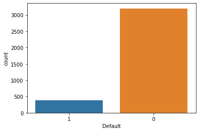

```python
ax = sns.countplot(x="Default", data=df)
```

```python
df_x = df.drop('Default', axis =1)
df_y = df['Default']
```

```python
df_x.head()
```

|  | Networth_Next_Year | Equity_Paid_Up | Networth | Capital_Employed | Total_Debt | Gross_Block | Net_Working_Capital | Curr_Assets | Curr_Liab_and_Prov | Total_Assets_to_Liab | ... | PBIDTM_perc_Latest | PBITM_perc_Latest | PBDTM_perc_Latest | CPM_perc_Latest | APATM_perc_Latest | Debtors_Vel_Days | Creditors_Vel_Days | Inventory_Vel_Days | Value_of_Output_to_Total_Assets | Value_of_Output_to_Gross_Block |
| --- | --- | --- | --- | --- | --- | --- | --- | --- | --- | --- | --- | --- | --- | --- | --- | --- | --- | --- | --- | --- | --- |
| 0 | -8021.60 | 419.36 | -7027.48 | -1007.24 | 5936.03 | 474.30 | -1076.34 | 40.50 | 1116.85 | 109.60 | ... | 0.00 | 0.00 | 0.00 | 0.00 | 0.00 | 0 | 0 | 45.00 | 0.00 | 0.00 |
| 1 | -3986.19 | 1954.93 | -2968.08 | 4458.20 | 7410.18 | 9070.86 | -1098.88 | 486.86 | 1585.74 | 6043.94 | ... | -10.30 | -39.74 | -57.74 | -57.74 | -87.18 | 29 | 101 | 2.00 | 0.31 | 0.24 |
| 2 | -3192.58 | 53.84 | 506.86 | 7714.68 | 6944.54 | 1281.54 | 4496.25 | 9097.64 | 4601.39 | 12316.07 | ... | -5279.14 | -5516.98 | -7780.25 | -7723.67 | -7961.51 | 97 | 558 | 0.00 | -0.03 | -0.26 |
| 3 | -3054.51 | 157.30 | -623.49 | 2353.88 | 2326.05 | 1033.69 | -2612.42 | 1034.12 | 3646.54 | 6000.42 | ... | -3.33 | -7.21 | -48.13 | -47.70 | -51.58 | 93 | 63 | 2.00 | 0.24 | 1.90 |
| 4 | -2967.36 | 50.30 | -1070.83 | 4675.33 | 5740.90 | 1084.20 | 1836.23 | 4685.81 | 2849.58 | 7524.91 | ... | -295.55 | -400.55 | -845.88 | 379.79 | 274.79 | 3887 | 346 | 0.00 | 0.01 | 0.05 |

5 rows × 65 columns

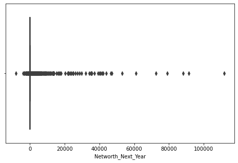

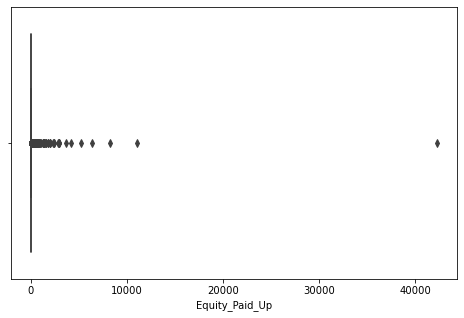

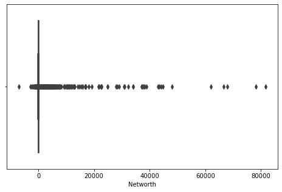

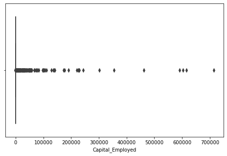

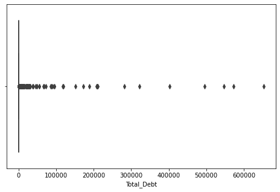

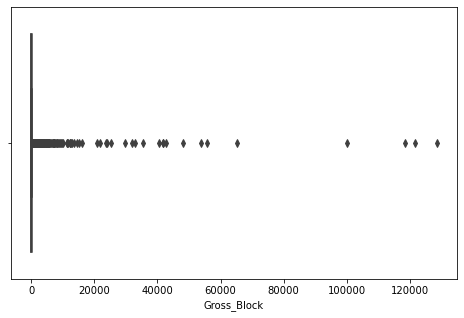

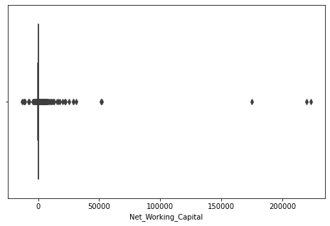

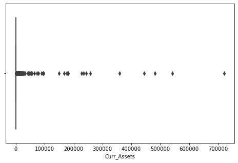

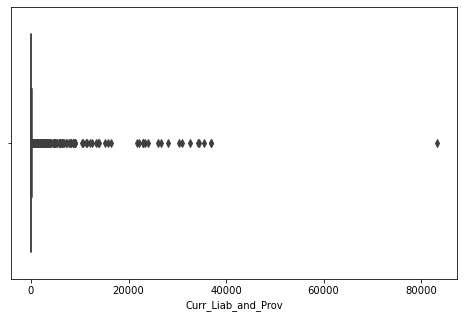

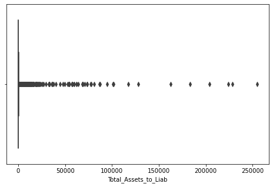

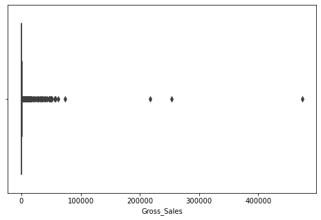

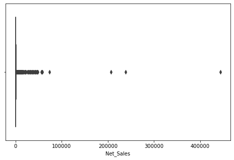

[53 more figures not shown]

```python
#Checking outliers

for x in df_x.columns:
    plt.figure(figsize=(8,5))
    sns.boxplot(df[x])
    plt.show()
```